# module3

GroupeB

2025-02-07

```r
df <- read.csv("College.csv")
head(df)
```

```
##                              X Private Apps Accept Enroll Top10perc Top25perc
## 1 Abilene Christian University     Yes 1660   1232    721        23        52
## 2           Adelphi University     Yes 2186   1924    512        16        29
## 3               Adrian College     Yes 1428   1097    336        22        50
## 4          Agnes Scott College     Yes  417    349    137        60        89
## 5    Alaska Pacific University     Yes  193    146     55        16        44
## 6            Albertson College     Yes  587    479    158        38        62
##   F.Undergrad P.Undergrad Outstate Room.Board Books Personal PhD Terminal
## 1        2885         537     7440       3300   450     2200  70       78
## 2        2683        1227    12280       6450   750     1500  29       30
## 3        1036          99    11250       3750   400     1165  53       66
## 4         510          63    12960       5450   450      875  92       97
## 5         249         869     7560       4120   800     1500  76       72
## 6         678          41    13500       3335   500      675  67       73
##   S.F.Ratio perc.alumni Expend Grad.Rate
## 1      18.1          12   7041        60
## 2      12.2          16  10527        56
## 3      12.9          30   8735        54
## 4       7.7          37  19016        59
## 5      11.9           2  10922        15
## 6       9.4          11   9727        55
```

## Exercice 1 :

Pour chacune des parties (a) à (d), indiquez si nous nous attendons généralement à ce que les performances d’une méthode d’apprentissage statistique flexible soient meilleures ou pires que celles d’une méthode rigide. Justifiez votre réponse.

(a)- La taille de l’échantillon est extrêmement grande et le nombre de prédicteurs est petit.

**Rép** : Si on a beaucoup de données et peu de prédicteurs, c’est mieux d’opter pour une méthode rigide. Cela évitera de trop s’adapter aux donner et créer des problèmes de sur ajustement.

(b)- Le nombre de prédicteurs est extrêmement grand et le nombre d’observations est petit

**Rép** : La méthode rigide est encore mieux. En effet, avec peu d’observations, une méthode flexible a assez de lattitude pour s’ajuster à l’ensemble des observations et mal généraliser.

(c)- La relation entre les prédicteurs et la réponse est fortement non linéaire.

**Rép**: La méthode flexible est meilleure afin de mieux capturer la complexité des relations.

(d)-La variance des termes d’erreur, c’est-à-dire , est extrêmement élevé

**Rép** : Si la variance est élevé cela signifie que il y a beaucoup de bruits donc en utilisant la méthode flexible, elle risque de faire un surajustement. Alors la méthode rigide est mieux adapter en sachant qu’elle est moins sensible au bruit.

## Exercice 2 :

Expliquez si chaque scénario est un problème de classification ou de régression, et indiquez si nous sommes plus intéressés par l’inférence ou la prédiction.

(a)-Nous collectons un ensemble de données sur les 500 plus grandes entreprises aux États-Unis. Pour chaque entreprise, nous enregistrons les bénéfices, le nombre d’employés, le secteur d’activité et le salaire du PDG. Nous souhaitons comprendre quels facteurs affectent le salaire du PDG.

**Rep**: C’est un problème de **regression**, par ce que le salaire est quantitatif continue. On veut faire une **inférence**. par ce que ce n’est pas le salaire en soi qui nous interesse, mais les variables qui le déterminent. La taille de l’échantillon n est 500 et le nombre de prédicteurs p est 4.

(b)-Nous envisageons de lancer un nouveau produit et souhaitons savoir si ce sera un succès ou un échec. Nous collectons des données sur 20 produits similaires précédemment lancés. Pour chaque produit, nous avons enregistré s’il s’agissait d’un succès ou d’un échec, le prix facturé pour le produit, le budget marketing, le prix de la concurrence et dix autres variables.

**Rép**: C’est un problème de **classification** (Succès ou échec), on veut faire une **prédiction**. La taille de l’échantillon n est 20 et le nombre de prédicteurs p est 13.

(c)- Nous souhaitons prédire la variation en % du taux de change USD/euro par rapport aux variations hebdomadaires des marchés boursiers mondiaux. C’est pourquoi nous collectons des données hebdomadaires pour toute l’année 2012. Pour chaque semaine, nous enregistrons le % de variation de la parité USD/Euro, le % de variation du marché américain, le % de variation du marché britannique et le % de variation du marché allemand.

## Exercice 3

```r
df <- data.frame(
  X1 = c(0, 2, 0, 0, -1, 1),
  X2 = c(3, 0, 1, 1, 0, 1),
  X3 = c(0, 0, 3, 2, 1, 1),
  Y = c("Rouge", "Rouge", "Rouge", "Vert", "Vert", "Rouge")
)
print(df)
```

```
##   X1 X2 X3     Y
## 1  0  3  0 Rouge
## 2  2  0  0 Rouge
## 3  0  1  3 Rouge
## 4  0  1  2  Vert
## 5 -1  0  1  Vert
## 6  1  1  1 Rouge
```

####a-Calculons la distance euclidienne entre chaque observation et le point de test

on sait que X1=X2=X3=0 donc le point de test (0,0,0).

On sait que la distance euclidienne entre deux observations est: distance <- sqrt(sum((x - y)^2))

```r
test <- c(0, 0, 0)
distances <- sqrt(rowSums((df[, 1:3] - test)^2))
df$Distance <- distances
print(df)
```

```
##   X1 X2 X3     Y Distance
## 1  0  3  0 Rouge 3.000000
## 2  2  0  0 Rouge 2.000000
## 3  0  1  3 Rouge 3.162278
## 4  0  1  2  Vert 2.236068
## 5 -1  0  1  Vert 1.414214
## 6  1  1  1 Rouge 1.732051
```

b-Quelle est notre prédiction avec K=1 Pourquoi?

####Pour K=1 la prédiction est vert

Car le point le plus proche de 1 est la distance de l’observation 5 de coordonner (−1,0,1) qui de 1.41 et de couleur vert.

c-Quelle est notre prédiction avec K=3 Pourquoi?

####Pour K=3 La prediction est Rouge

Car les 3 points les plus proches sont les observations 5, 6 et 2 avec des distances respectives Observation 5 (−1,0,1) distance 1.41 de couleur Vert Observation 6 (1,1,1) distance 1.73 de couleur Rouge Observation 2 (2,0,0) distance 2 de couleur Rouge et la couleur dominante est Rouge

d-Si la règle de décision de Bayes dans ce problème est hautement non linéaire, alors nous attendrions-nous à ce que la meilleure valeur pour soit grande ou petite ? Pourquoi?

Si la règle de décision de Bayes est hautement non linéaire, une petite valeur de k est préférable car Cela permet de mieux capturer les variations locales et les plus frontières complexes.

## Exercice 4

LA question est manquante

## Exercice 5

a-Aperçu des courbes typiques

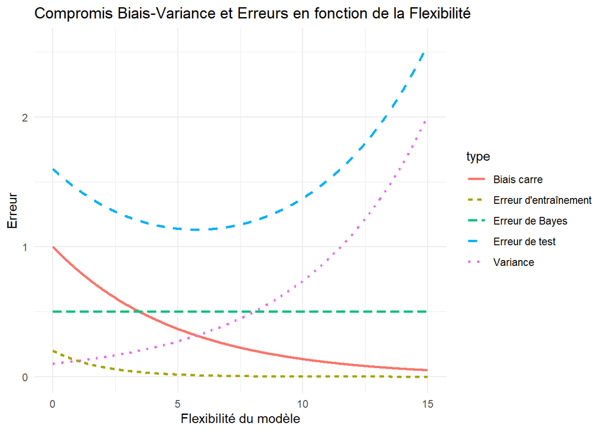

```r
# Chargement des bibliothèques
library(ggplot2)
library(dplyr)
# Définition la flexibilité (axe X)
variabitite <- seq(0, 15, length.out = 500)

# Définition des courbes
erreur_bayes <- rep(0.5, length(variabitite))  # Erreur de Bayes (constante)
biais_carre <- exp(-0.2 * variabitite)       # Biais(carré) diminue avec la flexibilité
variance <- 0.1 * exp(0.2 * variabitite)      # Variance augmente avec la flexibilité
erreur_entrainement <- 0.2 * exp(-0.5 * variabitite) # Erreur d'entraînement diminue
erreur_test <- biais_carre + variance + erreur_bayes  # Erreur de test = biais_carre + variance + erreur irréductible

# Création du DataFrame
df <- data.frame(
  variabitite = rep(variabitite, 5),
  erreur = c(biais_carre, variance, erreur_entrainement, erreur_test, erreur_bayes),
  type = rep(c("Biais carre", "Variance", "Erreur d'entraînement", "Erreur de test", "Erreur de Bayes"), each = length(variabitite))
)

# Tracé avec ggplot
ggplot(df, aes(x = variabitite, y = erreur, color = type, linetype = type)) +
  geom_line(size = 1) +
  labs(title = "Compromis Biais-Variance et Erreurs en fonction de la Flexibilité",
       x = "Flexibilité du modèle",
       y = "Erreur") +
  theme_minimal() #+
```

```r
  #theme(legend.title = element_blank())
```

b- Explication de la forme de chacune des cinq courbes affichées précédement:  
- Erreur de Bayes est constante, c’est l’erreur irréductible, ce qui se représente une droite horizontale - Biais carré diminue progressivement avec la flexibilité qui augmente ce qui est représenté par une fonction exponentielle - Variance augmente progressivement avec la flexibilité qui augmente - Erreur d’entraînement diminue avec la flexibilité qui augmente - Erreur de test est égale à biais_carre + variance + erreur irréductible, elle diminue à mesure que la flexibilité augmente atteignant sont minimum avant de croitre de nouveau à mesure que la flexibilité augmente.

## Exercice 6

Description de trois applications réelles dans lesquelles la classification pourrait êre utile 1- Classification des courriels (Spam vs Non-Spam) Problème : Filtrer les courriels indésirables (spam). Réponse (variable cible) : 1 = Spam 0 = Non-Spam Prédicteurs : Fréquence de certains mots-clés Adresse e-mail de l’expéditeur Présence de liens ou pièces jointes suspectes Longueur du message But : Prédiction L’objectif est de classer automatiquement les e-mails en fonction de leur contenu et d’éviter que des spams n’atteignent la boîte de réception. Il s’agit uniquement d’une prédiction, sans besoin d’inférer les causes sous-jacentes du spam.

2-Détection des faux passeport (Contrefait vs Original) Problème: Empêcher l’embarquement des passagers ayant de faux passeports Réponse(variable cible): 1 = Contrefait 0 = Original Prédicteurs: Numéro du passeport  
Présence des différents hologrammes de sécurité Nombres de visa But: Prédiction L’objectif est de reconnaitre automatique les faux passeports et éviter ainsi que leur détenteurs ne puissent voyager en utilisant la compagnie. Il s’agit ici uniquement de prédiction, sans inférence sur les causes sous-jacentes.

3-La détection de soudure défectueuses Problème: Empêcher la commercialisation d’équipement indusstriel non conforme Réponse(variable cible): 1 = Défectueuse 0 = Conforme Prédicteurs: taille de la soudure image de la soudure temps de refroidissement données ultrasons But: Prédiction et inférence L’objectif est de détecter précossement les défauts de soudure sur les pièces critiques avant d’éviter des bris sur des équipements stratégique de production. On s’interesse aussi aux causes.

Description de trois applications réelles dans lesquelles la regression pourrait êre utile 1- Prévision des prix des maisons Problème : Estimer le prix d’une maison en fonction de ses caractéristiques. Réponse (variable cible) : Prix de vente (en dollars) Prédicteurs : Surface habitable (m²) Nombre de chambres Nombre de salles de bains Localisation (quartier, proximité aux commerces, écoles) Année de construction État du bien (neuf, rénové, ancien) But : Prédiction L’objectif est de prédire le prix d’une maison en fonction des caractéristiques observées. Il n’est pas important de comprendre l’impact exact de chaque variable. Nous voulons juste obtenir une estimation précise du prix de la maison.

2- Prévision des prix d’une action à la bourse Problème: Estimer le prix d’une action en fonction des ses caractéristiques. Réponse(variable cible): Prix de vente de l’action Prédicteurs: directeur general nombre d’employés  
nouveaux contrat But: Prédiction L’objectif est de prédire le prix de vente d’une action.

3- Prévision du revenu Problème: Estimer le revenu futur d’un individu en fonction de ses caractéristiques. Réponse(variable cible): Montant du revenu annuel Prédicteurs: Niveau de scolaire date dernière formation domaine d’activité ancienneté revenu actuel employeur(salarié, travailleur autonome) But: Prédiction L’objectif est de déterminer le salaire future d’une personne connaissant ses caractéristiques. On ne s’interesse par aux niveau d’impacte de chacune de ses différentes variable.

## Exercice 7

Avantages et inconvénients d’une approche très flexible (par rapport à une approche moins flexible) de régression ou de classification Avantages: Faible biais Meilleur ajustement aux données (bon apprentissage) Performance accrue sur des données riches Inconvenients: Overfitting(sur ajustement au données d’entrainement) consommation accrue des ressources de calculs Besoin d’une grande quantité de données

On choisira un modèle plus flexible lorsque l’on a beaucoup de données et que l’on a pas une relation évidente entre les variable. On choisira un modèle moins fexible lorsque l’on a peut de données et que l’interprétation des données est cruciale.

## Exercice 8

Avantages d’une approche paramétrique en régression ou classification: - Moins de risque de sur-apprentissage (Overfitting) - Rapidité d’entraînement et d’inférence - Facilité d’interprétation - Moins de données nécessaires Inconvenients d’une approche paramétrique en régression ou classification: - Plus de risque de sous-apprentissage (Underfitting) - s’ajuste mal sur des données complexes

## Pratique

```r
#importation des données
college <- read.csv("College.csv")
#visualisation des données
#View(college)
#changement du nom des lignes
rownames(college) = college[,1]
# suppression de la colonne x
college= college[, -1]
View(college)
```

c

```r
#résumé numérique des données
table(summary(college))
```

[output not shown]

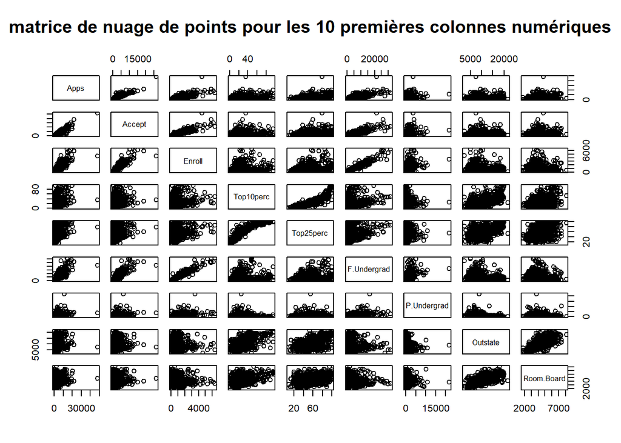

```r
#Afficher la matrice de nuage de points pour les 10 premières colonnes numériques
college_10_first = college[,1:10]
college_10_first_numeric <- college_10_first[, sapply(college_10_first, is.numeric)]
pairs(college_10_first_numeric, main="matrice de nuage de points pour les 10 premières colonnes numériques")
```

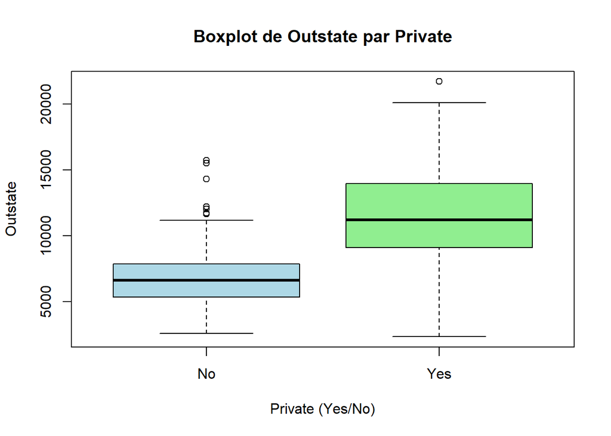

```r
#boxplot cote à cote
#plot(Outstate~Private, data=college, main= "Boxplot de Outstate par Private",
#     xlab = "Private(Yes/No)", ylab = "Outstate", col=c("lightblue", "lightgreen"),
#     ylim(range(college$Outstate,na.rm = TRUE)))
college$Private = as.factor(college$Private)
plot(Outstate~Private, data = college, main = "Boxplot de Outstate par Private",
    xlab = "Private (Yes/No)", ylab = "Outstate", col = c("lightblue", "lightgreen"),
    ylim(range(college$Outstate,na.rm = TRUE)))
```

```r
#ggplot(college, aes(x = Private, y = Outstate, fill = Private)) +
#  geom_boxplot() +
#  theme_minimal() +
#  labs(title = "Boxplots de Outstate en fonction de Private") +
#  facet_wrap(~Private, scales = "fixed")


#creation de la variable Elite
Elite <- rep("No", nrow(college))
Elite[college$Top10perc > 50] <- "Yes"
Elite <- as.factor(Elite)
college <- data.frame(college, Elite)

#Nombre d'université d'elite
summary(college$Elite)[2]
```

```
## Yes
##  78
```

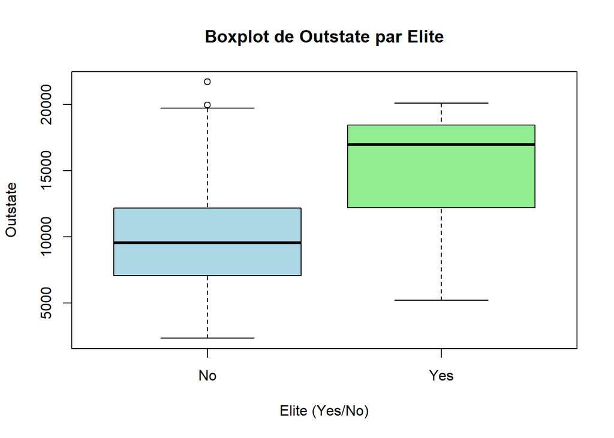

```r
#boxplot cote à cote de Outstate et Elite
plot(Outstate~Elite, data = college, main = "Boxplot de Outstate par Elite",
    xlab = "Elite (Yes/No)", ylab = "Outstate", col = c("lightblue", "lightgreen"),
    ylim(range(college$Outstate,na.rm = TRUE)))
```

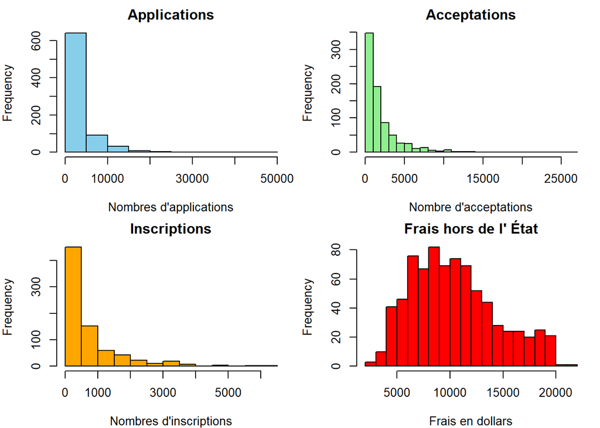

```r
#ggplot(college, aes(x = Elite, y = Outstate, fill = Elite)) +
#  geom_boxplot() +
#  theme_minimal() +
#  labs(title = "Boxplots de Outstate en fonction de ") +
#  facet_wrap(~Private, scales = "fixed")

# Les 4 histogrammes en fonction des variables quantitatives suivantes: l'application, l'acceptation, l'inscription puis les frais en dehors de l'État

par(mar=c(4,4,2,1)) #pour réduire les marges
par(mfrow=c(2,2)) #Diviser la fenêtre en 2 lignes et 2 colonnes
hist(college$Apps,breaks=15,col="skyblue",main="Applications",xlab="Nombres d'applications")

hist(college$Accept,breaks=20,col="lightgreen",main="Acceptations",xlab="Nombre d'acceptations")

hist(college$Enroll,breaks=10,col="orange",main="Inscriptions",xlab="Nombres d'inscriptions")

hist(college$Outstate,breaks=25,col="red",main="Frais hors de l' État",xlab="Frais en dollars")
```

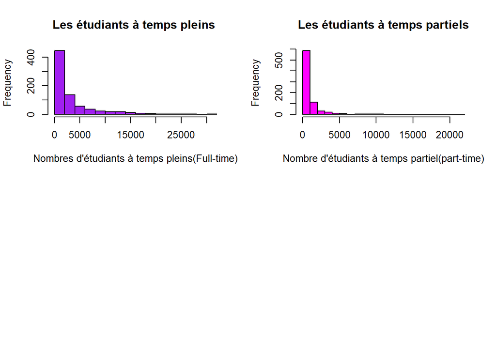

```r
# Les étudiants à temps pleins vs les étudiants à temps partiel
par(mfrow=c(2,2))
hist(college$F.Undergrad,breaks=15,col="purple",main="Les étudiants à temps pleins ",xlab="Nombres d'étudiants à temps pleins(Full-time)")

hist(college$P.Undergrad,breaks=20,col="magenta",main="Les étudiants à temps partiels",xlab="Nombre d'étudiants à temps partiel(part-time)")
```

Les histogrammes montrent le nombre d’etudiants dans une université selon leur durée passée aux études. On constate que la majorité des étudiants à l’université sont à temps pleins, le nombres d’étudiants à temps pleins peuvent s’étaler jusqu’à plus de 25000 étudiants.

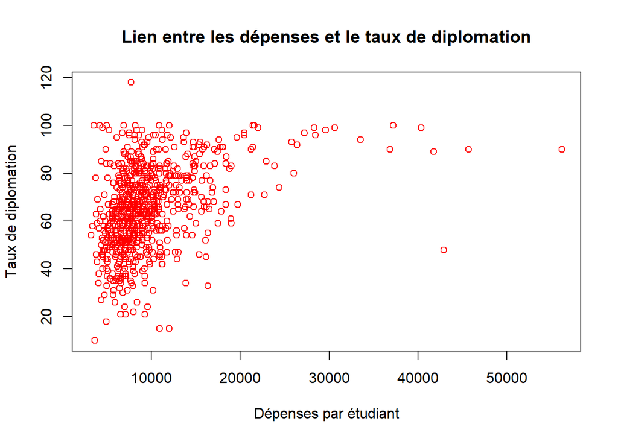

```r
plot(college$Expend,college$Grad.Rate,
     main = "Lien entre les dépenses et le taux de diplomation",
     xlab = "Dépenses par étudiant", ylab = "Taux de diplomation",
     col = "red")
```

```r
cor(college$Expend, college$Grad.Rate)
```

```
## [1] 0.3903427
```

Le nuage de point montre un lien entre les dépenses que fait une université par étudiant et le taux de diplomation. Cependant, la corrélation de 0.39 est faible ce qui démontre que les universités qui investissent plus par étudiant ont un taux de diplomation légèrement plus élevé .Donc, les dépenses par étudiant ne sont pas un facteur déterminant dans la réussite d’un étudiant.